# Plot-Types for Generalized Linear Models

Daniel Lüdecke

2017-02-03

This document shows examples for using the `sjp.glm()` function of the sjPlot package. However, many other functions for plotting regression models, like `sjp.lm()`, `sjp.lmer()` or `sjp.glmer()` work in a similar way and also offer the various plot-types (predictions, marginal effects, fixed effects…).

```r
library(sjPlot)
library(sjmisc)
data(efc)
# set basic theme options
set_theme("forest",
          axis.title.size = .85,
          axis.textsize = .85,
          legend.size = .8,
          geom.label.size = 3.5)
```

## Fitting a logistic model

First, we fit a binomial logit-model and create a vector with labels for the predictors.

```r
# create binary response
y <- ifelse(efc$neg_c_7 < median(na.omit(efc$neg_c_7)), 0, 1)
# create data frame for fitting model
df <- data.frame(y = to_factor(y),
                 sex = to_factor(efc$c161sex),
                 dep = to_factor(efc$e42dep),
                 barthel = efc$barthtot,
                 education = to_factor(efc$c172code))
# set variable label for response
set_label(df$y) <- "High Negative Impact"
# fit model
fit <- glm(y ~.,
           data = df,
           family = binomial(link = "logit"))
```

## Plotting estimates of generalized linear models

With the `sjp.glm()` function you can plot the odds ratios (or e.g. incidents ratios for poisson models) with confidence intervals as so called *forest plots*.

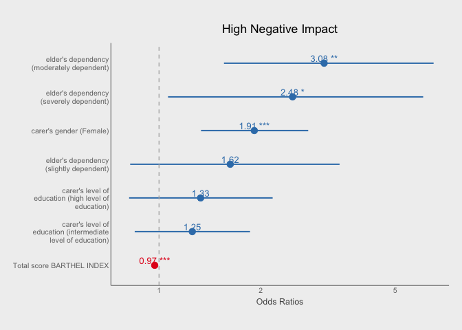

```r
sjp.glm(fit)
```

## Plotting incident rate ratios (Poisson)

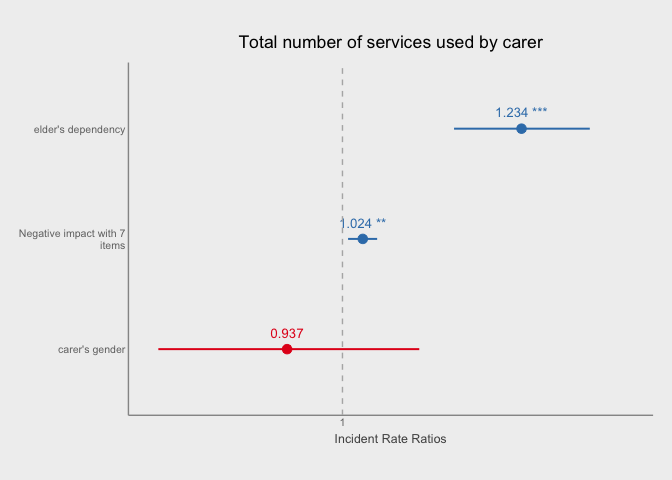

```r
# set variable label for service usage
set_label(efc$tot_sc_e) <- "Total number of services used by carer"

# fit poisson model
fit2 <- glm(tot_sc_e ~ neg_c_7 + e42dep + c161sex,
            data = efc, family = poisson(link = "log"))
# fit incident rate ratios, we need three decimal points to see
# a difference to the negative binomial model...
sjp.glm(fit2, digits = 3)
```

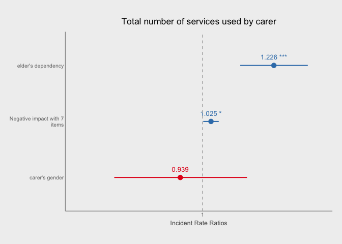

```r
# fit negative binomial model as well
library(MASS)
fit3 <- glm.nb(tot_sc_e ~ neg_c_7 + e42dep + c161sex, data = efc)
# fit incident rate ratios
sjp.glm(fit3, digits = 3)
```

## Continuous values at the axis

Due to the log-scaling of the x-axis - which should be done when plotting odds ratios (see [here](http://aje.oxfordjournals.org/content/early/2011/06/29/aje.kwr156.long) and [here](http://www.ncbi.nlm.nih.gov/pmc/articles/PMC1127651/)) - the x-axis values have an exponential growth. However, you can transform the ticks with `trns.ticks` (defaults to `TRUE`) to get proportional distances between the values. The x-axis-tick marks are set accordingly.

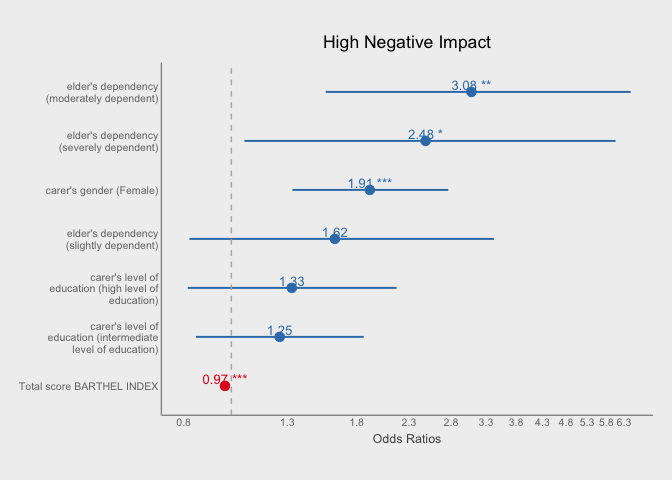

```r
sjp.glm(fit, trns.ticks = FALSE)
```

## Sorting estimates

By default, the odds ratios are sorted from highest to lowest value. You can also keep the order of predictors as they were introduced into the model if you set `sort.est` to `FALSE`.

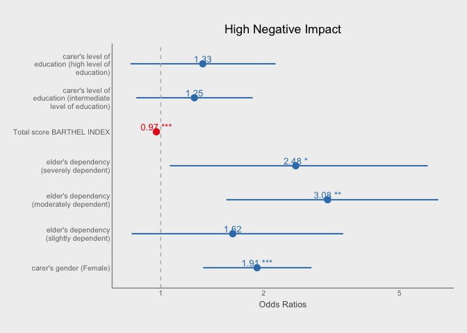

```r
sjp.glm(fit, sort.est = FALSE)
```

## Predictions of coefficients

### Predicted probabilities or incidents

The predicted values from this plot type are based on the intercept’s estimate and each specific term’s estimate. All other co-variates are set to zero (i.e. ignored), which corresponds to `family(fit)$linkinv(eta = b0 + bi * xi)` (where `xi` is the estimate).

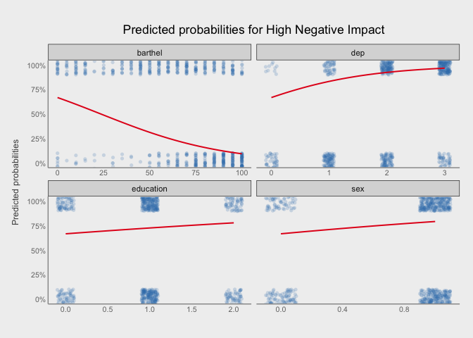

```r
sjp.glm(fit, type = "slope")
```

A probability curve of all predictors is plotted, which indicates the probability that the event (indicated by the response) occurs for each value of the predictor (*not* adjusted for remaining co-variates). In the above example, the first facet plot would be interpreted as: with increasing Barthel-Index (which means, better functional / physical status), the probability that caring for a dependent person is negatively perceived, decreases (in short: the less dependent a person I care for is, the less negative is the impact of care).

This kind of plot may be more informative then the odds ratio of `0.97` for the predictor *Total score BARTHEL INDEX*.

The same works for other model families or link functions. The following shows predicted incidents from the poisson model.

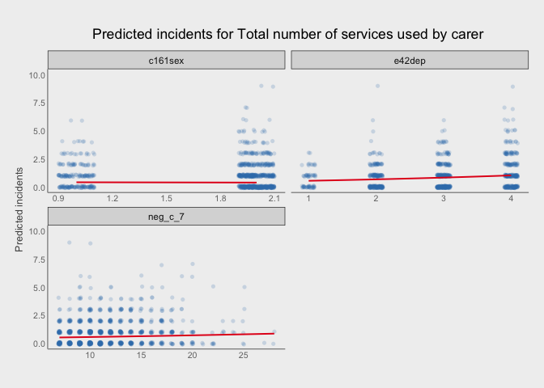

```r
sjp.glm(fit2, type = "slope")
```

Confidence intervals are shown when `show.ci = TRUE`, and data points are not plotted when `show.scatter = FALSE`. You can also plot single plots for each coefficient when `facet.grid = FALSE`. To get selected plots for particular predictors only, pass the term names to the `vars` argument. In the following example, only the relationship between *barthel* and negative impact is shown.

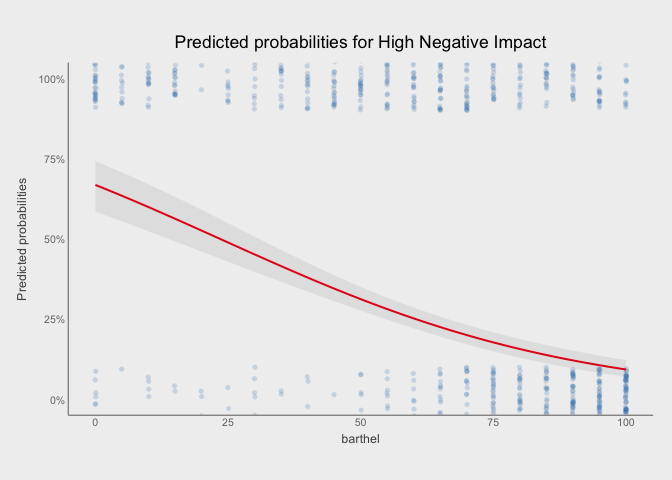

```r
sjp.glm(fit, type = "slope", facet.grid = FALSE,
        show.ci = TRUE, vars = "barthel")
```

### Marginal effects

With `type = "eff"`, you can plot marginal effects (predicted marginal probabilities resp. predicted marginal incident rates), where all remaining co-variates are set to the mean. Unlike `type = "slope"`, this plot type adjusts for co-variates.

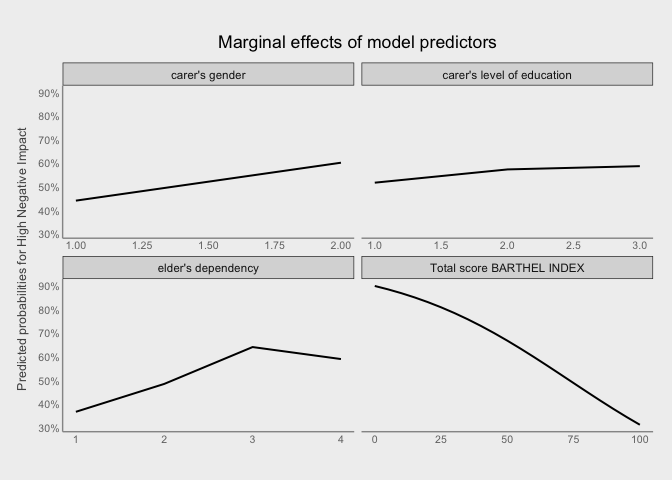

```r
# the binary outcome
sjp.glm(fit, type = "eff")
```

As you can see in the above examples, multiple plots for `type = "eff"` are plotted as [facet grid](http://docs.ggplot2.org/current/facet_grid.html) resp. as [facet wrap](http://docs.ggplot2.org/current/facet_wrap.html). Since this does not allow to set a different x-scale for each plot, x-axis are not properly labelled. However, `facet.grid = FALSE` produces a single plot for each predictor:

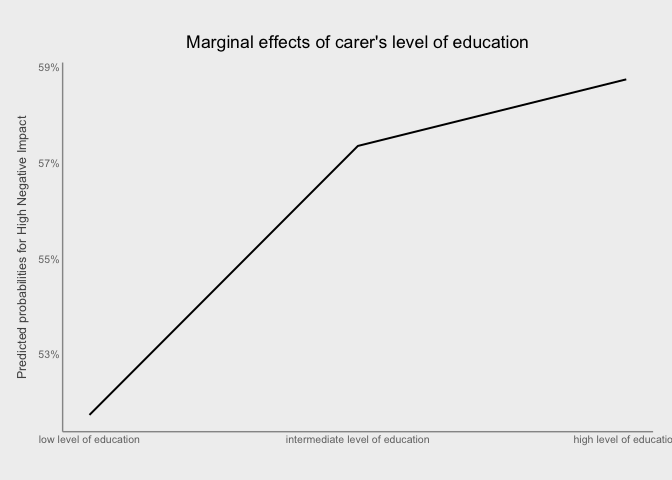

```r
# plot marginal effects, but only for dependency this time
sjp.glm(fit, type = "eff", facet.grid = FALSE, vars = "education")
```

To arrange all predictors of multiple in one plot, as grid, use the `plot_grid()` function *on multiple plot objects*. `plot_grid()` requires multiple plots, so you have to set `facet.grid = FALSE` to get a `plot.list`-value as return value from the function (see `?sjp.lm` on *Return Value* for more details). This allows you arrange multiple plots as grid in one plot, but with different x-axis-scales.

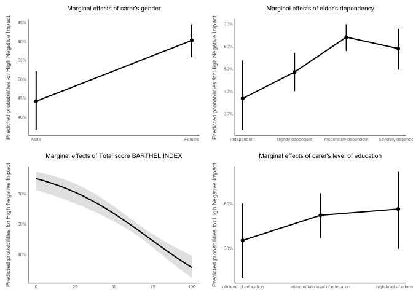

```r
# get list of all plots
p <- sjp.glm(fit, type = "eff", facet.grid = FALSE,
             show.ci = TRUE, prnt.plot = FALSE)$plot.list
# plot all marginal effects, as grid, proper x-axes
# also, set margins for this example
plot_grid(p, margin = c(0.3, 0.3, 0.3, 0.3))
```

### Predicting values

With `type = "pred"`, you can plot predicted values for the response, related to specific model predictors. The predicted values of the response are computed, based on the `predict.glm` method and corresponds to `predict(fit, type = "response")`. This plot type requires the `vars` argument to select specific terms that should be used for the x-axis and - optional - as first or second grouping factor. Hence, `vars` must be a character vector with the names of one to three model predictors.

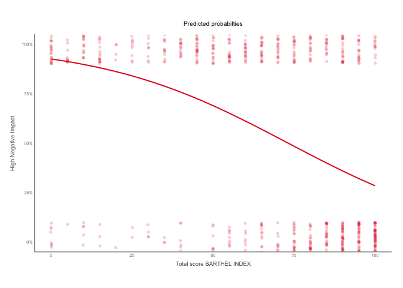

```r
# the binary outcome
sjp.glm(fit, type = "pred", vars = "barthel")
```

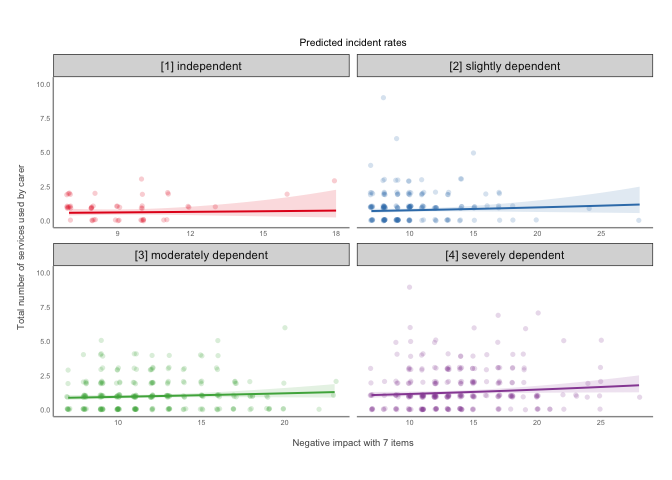

```r
# the count outcome
sjp.glm(fit3, type = "pred", vars = c("neg_c_7", "e42dep"),
        show.ci = TRUE)
```

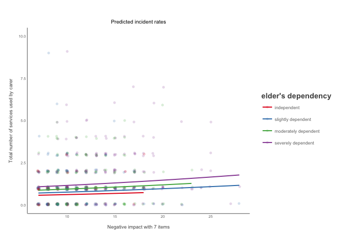

```r
# the count outcome, non faceted
sjp.glm(fit2, type = "pred", vars = c("neg_c_7", "e42dep"),
        facet.grid = FALSE)
```

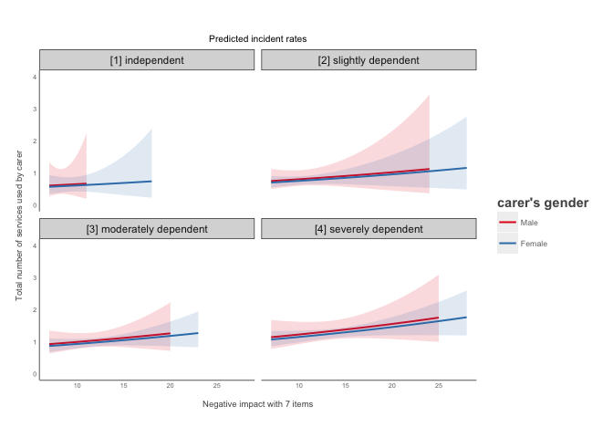

```r
# the count outcome, grouped gender and education, w/o data points
# and adjusted y-limits, to completely show CI bands
sjp.glm(fit2, type = "pred", vars = c("neg_c_7", "c161sex","e42dep"),
        facet.grid = FALSE, show.ci = TRUE, show.scatter = FALSE,
        axis.lim = c(0, 4))
```